# Triploid paper analysis

### Reading data for aberrations per chromosome and plotting the results

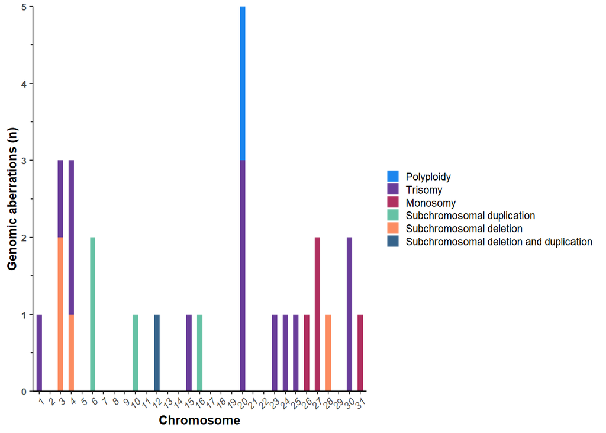

```r
#reading data
dat_chr<-read.csv ("ploidy information_per_chr.csv")

#Creating a plot

dat_chr_plot<-dat_chr[6:36]
chr_melt <- melt(dat_chr_plot, measure.vars= c("Chr1", "Chr2", "Chr3", "Chr4", "Chr5", "Chr6", "Chr7", "Chr8", "Chr9", "Chr10", "Chr11", "Chr12", "Chr13", "Chr14", "Chr15", "Chr16", "Chr17", "Chr18", "Chr19", "Chr20", "Chr21", "Chr22", "Chr23", "Chr24", "Chr25", "Chr26", "Chr27", "Chr28", "Chr29", "Chr30", "Chr31"), na.rm = F)

names(chr_melt) <- c ("Chromosome", "Aberration")

chr_melt$Aberration<-factor(chr_melt$Aberration, levels = c("Polyploidy", "Trisomy", "Monosomy", "Subchromosomal duplication", "Subchromosomal deletion", "Subchromosomal deletion and duplication"))

levels(chr_melt$Chromosome) <- 1:31

chr_melt$Aberration <- as.character(chr_melt$Aberration)
chr_melt$Aberration [which(is.na(chr_melt$Aberration))] <-"0"


chr_melt <- chr_melt %>%
  count(Chromosome, Aberration) %>%
  complete(Chromosome, Aberration, fill = list(n = 0)) %>%
  mutate(n = ifelse(n > 5, 0, n))%>%
  filter(Aberration != "0")

chr_melt$Aberration<-factor(chr_melt$Aberration, levels = c("Polyploidy", "Trisomy", "Monosomy", "Subchromosomal duplication", "Subchromosomal deletion", "Subchromosomal deletion and duplication"))


fill_palette <-c("#1C86EE", "#6A3D9A", "#B03060","#66C2A5", "#FC8D62",  "#36648B")

p <- ggplot(data = chr_melt, aes(x = Chromosome, y = n, fill = Aberration))
p = p + geom_bar(stat = "identity", position = "stack", width = 0.5)
p = p + scale_y_continuous("Genomic aberrations (n)", expand = c (0, 0), limits = c (0, 5))
p = p + scale_x_discrete("Chromosome")
p = p + scale_fill_manual(values = fill_palette,
                           guide = guide_legend( keywidth = 0.75, keyheight = 0.75, title = ""))
p = p + theme(axis.text.x = element_text(size = 8, face = "italic", hjust = 1, angle = 45))
p = p + guides(x = "axis_minor", y = "axis_minor")
p = p + theme(legend.background = element_rect(fill = "white"))
p
```

### Create a plot for triploid, aneuploid and diploid within each of the age category

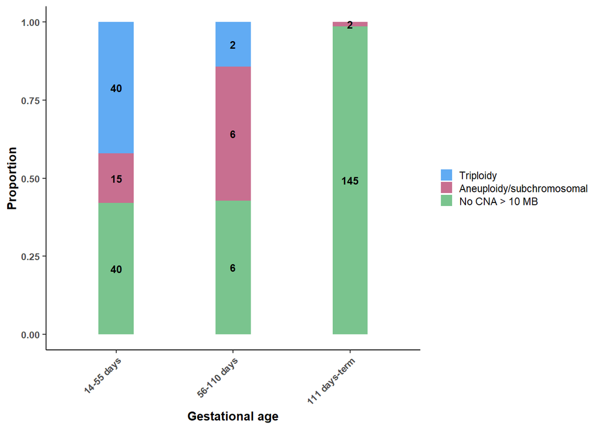

```r
test <- data.frame(
  Gestational_age = c("14-55 days", "56-110 days", "111 days-term"),
  Aneuploidy = c(15, 6, 2),
  Triploidy = c(40, 2, 0),
  Normal = c(40, 6, 145)
)

# Calculate total for each age category
test <- test %>%
  mutate(total = rowSums(select(., -Gestational_age)))

# Calculate percentage of each ploidy status for each age category
test_percent  <- test %>%
  mutate_at(vars(-Gestational_age, -total), ~./total)

# Reshape data for plotting
dat_chr_long <- test %>%
  pivot_longer(cols = -c(Gestational_age, total),
               names_to = "ploidy_status",
               values_to = "count") %>%
  left_join(test_percent %>%
              pivot_longer(cols = -c(Gestational_age, total),
                           names_to = "ploidy_status",
                           values_to = "percentage"),
            by = c("Gestational_age", "ploidy_status"))

dat_chr_long$ploidy_status<- factor (dat_chr_long$ploidy_status, levels = c( "Triploidy", "Aneuploidy", "Normal"), labels = c("Triploidy", "Aneuploidy/subchromosomal", "No CNA > 10 MB"))

dat_chr_long$Gestational_age<-factor (dat_chr_long$Gestational_age, levels = c("14-55 days", "56-110 days", "111 days-term"))

# Define fill colors

my_palette <- c("No CNA > 10 MB" = "#41AB5D", "Aneuploidy/subchromosomal" = "#B03060", "Triploidy" = "#1C86EE")

# Plot
p2 <- ggplot(dat_chr_long, aes(x = Gestational_age, y = percentage, fill = ploidy_status)) +
  geom_bar(stat = "identity" , width = 0.3, alpha = 0.7) +
  scale_fill_manual(values = my_palette, guide = guide_legend( keywidth = 0.75, keyheight = 0.75, title = "")) +
  labs(x = "Gestational age",
       y = "Proportion") +
  theme(axis.text.x = element_text(angle = 45, hjust = 1)) +
  geom_text(data = subset(dat_chr_long, count != 0), aes(label = count),
            position = position_stack(vjust = 0.5), size = 3, color = "black", fontface = "bold", family = "Arial")
p2
```

### Create boxplots for paternal and maternal age and split it by normal, aneuploidy including sub-chromosomal aberrations and triploidy

```r
table (mydata_uniq$ploidy_recat)
```

```
##
## Aneuploidy/subchromosomal            No CNA > 10 MB                 Triploidy
##                        23                       191                        42
```

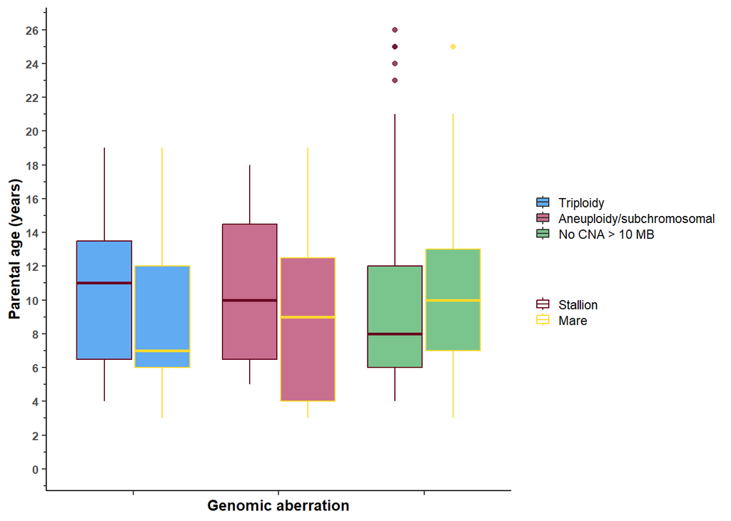

```r
my_palette <- c("No CNA > 10 MB" = "#41AB5D", "Aneuploidy/subchromosomal" = "#B03060", "Triploidy" = "#1C86EE")
df1 <- melt(mydata_uniq, id.vars=c("ploidy_recat"), measure.vars=c("Stallion.age", "Mare.age.at.conception"))

df1$ploidy_recat <- factor (df1$ploidy_recat, levels = c ( "Triploidy", "Aneuploidy/subchromosomal",  "No CNA > 10 MB"))

df1$variable <- factor (df1$variable, levels = c ("Stallion.age", "Mare.age.at.conception"), labels = c ("Stallion", "Mare"))

p <- ggplot(data = df1, aes(y= value , x=ploidy_recat,  color = variable, fill = ploidy_recat)) +
  scale_y_continuous(limits = c (0, 26), breaks = c (0, 2, 4, 6, 8, 10, 12, 14, 16, 18, 20, 22, 24, 26))+
  geom_boxplot(position = position_dodge(width = 0.8), alpha = 0.7) +
  scale_fill_manual(values = my_palette, guide = guide_legend( keywidth = 0.75, keyheight = 0.75, title = "")) +
  labs(x = "Genomic aberration",
       y = "Parental age (years)") +
  guides(y = "axis_minor")+
  scale_color_manual(values = c ("#67001F" , "#FFD92F"), guide = guide_legend( keywidth = 0.75, keyheight = 0.75, title = "")) +
  theme(axis.text.x = element_blank())
p
```

### Create barplot of age at pathology split into weeks upto 10 weeks

```r
mydata_uniq <- mydata_uniq %>%
  mutate(age_by_week = cut(age_at_pathology,
                           breaks = seq(0, 355, by = 7),  # Breaks for each week
                           labels = paste0(1:50)))  # Labels for each week


mydata_uniq$ploidy_status <- factor (mydata_uniq$ploidy_status, levels = c ("aneuploid", "triploid", "diploid"))
table (mydata_uniq$age_by_week, mydata_uniq$ploidy_status)
```

```
##
##      aneuploid triploid diploid
##   1          0        0       0
##   2          2        0       0
##   3          0        0       3
##   4          1        7       3
##   5          4        3      10
##   6          8       20      12
##   7          0        9      12
##   8          0        1       0
##   9          4        1       0
##   10         2        1       5
##   11         0        0       0
##   12         0        0       0
##   13         0        0       1
```

[output cut: 37 more lines]

```r
weeks<-c ("1", "2", "3", "4", "5", "6", "7", "8", "9", "10")
dat<-mydata_uniq%>%
  filter (age_by_week %in% weeks) %>%
  droplevels()%>%
  filter (Ploidy_new != "Normal")

table(dat$Ploidy_new)
```

```
##
##        Monosomy Sub_Chromosomal       Triploidy         Trisomy
##               4               5              42              12
```

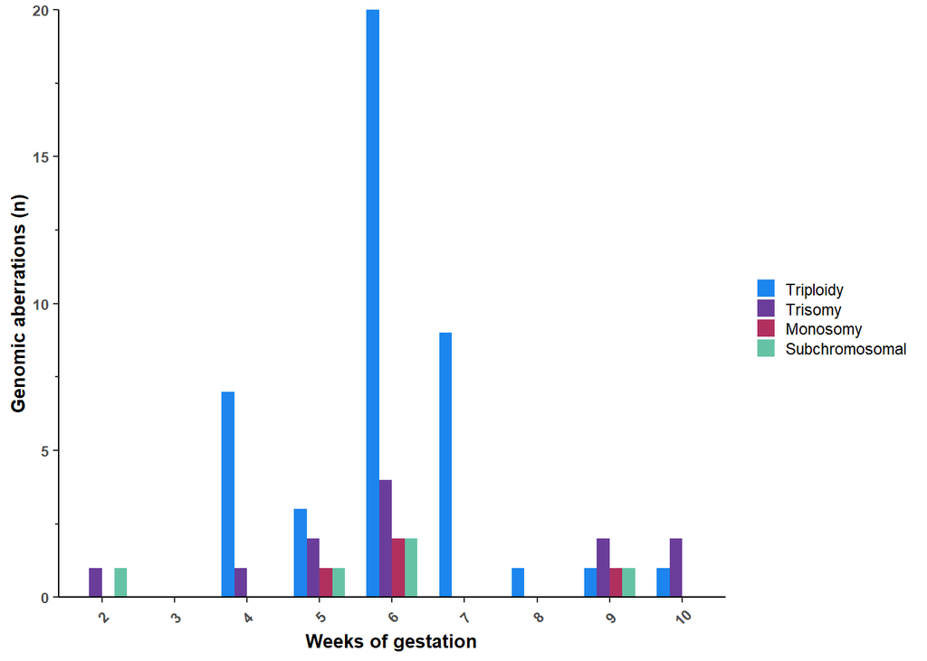

```r
dat$Ploidy_new <- factor (dat$Ploidy_new, levels = c ("Triploidy", "Trisomy", "Monosomy", "Sub_Chromosomal"), labels = c ("Triploidy", "Trisomy", "Monosomy", "Subchromosomal"))


dat_melt <- dat %>%
  count(age_by_week, Ploidy_new) %>%
  complete(age_by_week, Ploidy_new, fill = list(n = 0))


fill_palette <-c("#1C86EE", "#6A3D9A", "#B03060","#66C2A5", "#FC8D62",  "#36648B")

p <- ggplot(data = dat_melt, aes(x = age_by_week, y = n, fill = Ploidy_new))
p = p + geom_bar(stat = "identity", position = "dodge", width = 0.7)
p = p + scale_y_continuous("Genomic aberrations (n)", expand = c (0, 0), limits = c (0, 20))
p = p + scale_x_discrete("Weeks of gestation")
p = p + scale_fill_manual(values = fill_palette,
                           guide = guide_legend( keywidth = 0.75, keyheight = 0.75, title = ""))
p = p + guides(x = "axis_minor", y = "axis_minor")
p = p + theme(legend.background = element_rect(fill = "white"))
p = p + theme(axis.text.x = element_text(angle = 45, hjust = 0.5, vjust = 0.5, family = "Arial", size = 8))
p
```

### Plot inoformaton about wether triploidy poc were embryonic or not and results of morpholgical exam of embryonic ones

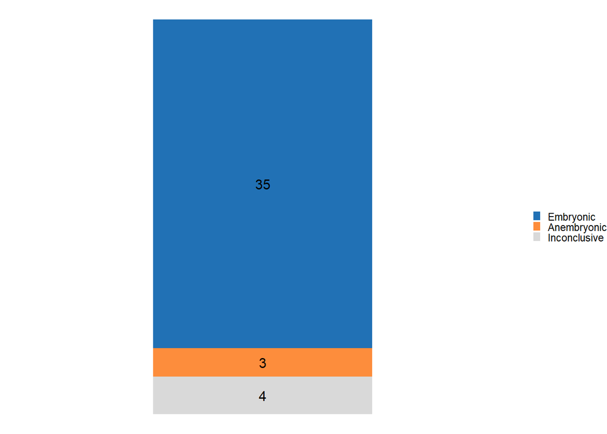

```r
df<- data.frame (
  Fetus_present = c ("Embryonic", "Anembryonic", "Inconclusive"),
count_fetus = c (35, 3, 4))

df$Fetus_present <- factor (df$Fetus_present, levels = c ("Embryonic", "Anembryonic", "Inconclusive"))


p <- ggplot(df, aes(x = "", y = count_fetus, fill = Fetus_present)) +
  geom_bar(stat = "identity", width = 0.5) +
  geom_text(aes(label = count_fetus), position = position_stack(vjust = 0.5), color = "black", size = 4, stat = "identity") +  # Add text labels
  labs(x = NULL, y = NULL) +
  scale_fill_manual(values = c("#2171B5" , "#FD8D3C",  "#D9D9D9"),
                    guide = guide_legend( keywidth = 0.5, keyheight = 0.5, title = "")) +
  theme_void()
p
```

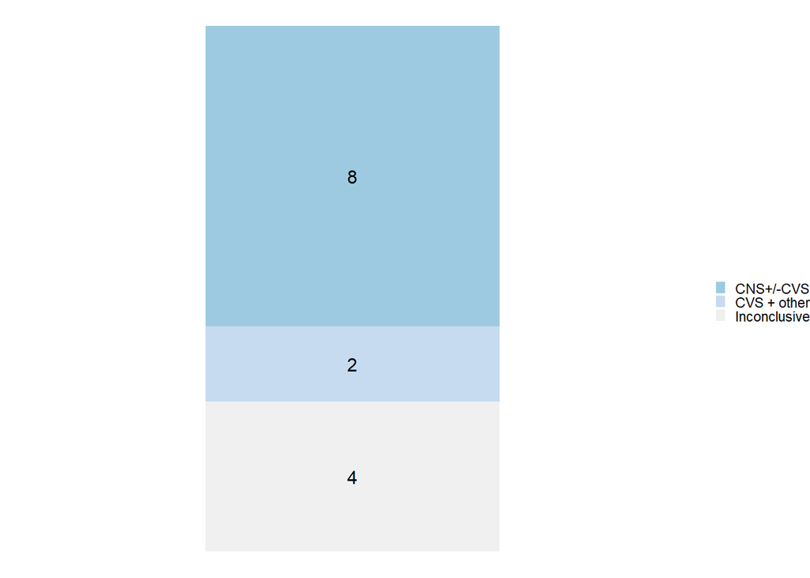

```r
#Morphological assessment of 14 fetuses


df_anomaly<- data.frame (
  Fetus_anomlay = c ("CNS+/-CVS", "CVS + other", "Inconclusive"),
count_anomlay = c (8, 2, 4)) # # This data summary is collated from this and previously published work see DOI: 10.1111/evj.13340

df_anomaly$Fetus_anomlay <- factor (df_anomaly$Fetus_anomlay, levels = c ("CNS+/-CVS", "CVS + other", "Inconclusive"))

p <- ggplot(df_anomaly, aes(x = "", y = count_anomlay, fill = Fetus_anomlay)) +
  geom_bar(stat = "identity", width = 0.5) +
  geom_text(aes(label = count_anomlay), position = position_stack(vjust = 0.5), color = "black", size = 4, stat = "identity") +  # Add text labels
  labs(x = NULL, y = NULL) +
  scale_fill_manual(values = c("#9ECAE1" , "#C6DBEF",  "#F0F0F0"),
                    guide = guide_legend( keywidth = 0.5, keyheight = 0.5, title = "")) +
  theme_void()
p
```

### Create a pie chart for distribution of sex in triploidy product of conceptus

```r
dat<-subset (mydata_uniq, Ploidy_new == "Triploidy" )

table (dat$SEX_Genotype_collated)
```

```
##
## XXX XXY
##  23  19
```

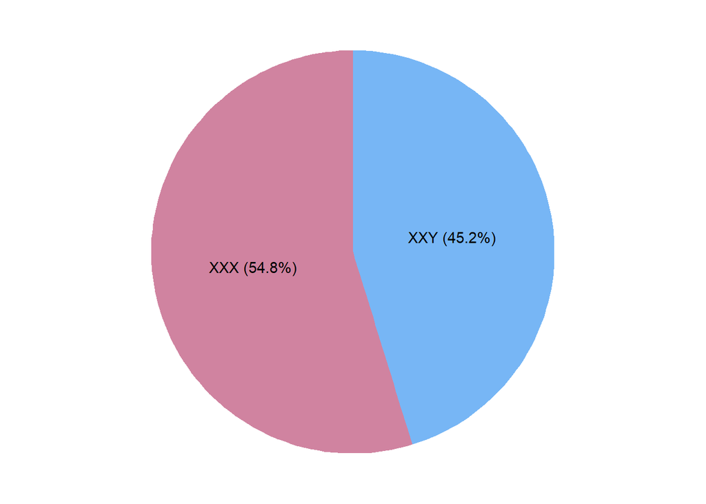

```r
# Given data
counts <- c(23, 19)
categories <- c("XXX", "XXY")

# Create a data frame
pie_data <- data.frame(categories, counts)

# Calculate percentages
pie_data <- pie_data %>%
  mutate(percentage = counts / sum(counts) * 100)

# Plotting the pie chart with labels
p<-ggplot(pie_data, aes(x = "", y = counts, fill = categories, label = paste(categories, sprintf("(%1.1f%%)", percentage)))) +
  geom_bar(stat = "identity", width = 1, alpha = 0.6) +
  coord_polar("y", start = 0) +
  geom_text(position = position_stack(vjust = 0.5), color = "black") +
  labs(fill = "Genotype") +
  theme_void() +
  theme(legend.position = "none")+
  scale_fill_manual(values = c ("#B03060", "#1C86EE"))
 p
```

### Investigate if multiple samples from the same POC had consistent genetic testing results

```r
## Examine which samples had fetal and placental tissue tested and see if the results matches up

mydata_dub<-mydata %>%
  mutate(duplicate_epl = ifelse(duplicated(lab_code) | duplicated (lab_code, fromLast = TRUE), "yes", "no"))

table (mydata_dub$duplicate_epl) #86 lab codes are repeated
```

```
##
##  no yes
## 215  86
```

```r
length (unique (mydata_dub$lab_code[mydata_dub$duplicate_epl=="yes"])) # 41 unique POC had  multiple tissues been tested
```

```
## [1] 41
```

```r
consis<- mydata_dub[c("Sample.Filename", "duplicate_epl", "Tissue", "lab_code","ploidy_status", "Ploidy_status_combined", "Tissue_fetus_placenta", "Ploidy_new", "STR_combined", "age_at_path_cat")]
dim (consis)
```

```
## [1] 301  10
```

```r
consis<-subset (consis, duplicate_epl == "yes")
dim (consis)
```

```
## [1] 86 10
```

```r
table (consis$Tissue_fetus_placenta)
```

```
##
##    Fetus Placenta  Unknown
##       44       41        1
```

```r
#creates a variable to define how many distinct lab_codes had both fetus and placenta being tested through counting number of distinct tissues in the tissue_fetus_placenta variable

consis <- consis %>%
  group_by(lab_code) %>%
  mutate(duplicate_with_different_values = ifelse(n_distinct(Tissue_fetus_placenta) > 1, "yes", "no"))

table (consis$duplicate_with_different_values)
```

```
##
##  no yes
##  21  65
```

```r
#see if ploidy stats consistent

consis_ploidy<-subset (consis, duplicate_with_different_values == "yes")
dim (consis_ploidy)
```

```
## [1] 65 11
```

```r
consis_ploidy<-consis_ploidy%>%
  group_by(lab_code)%>%
  mutate (ploidy_consistent = ifelse (n_distinct(ploidy_status )> 1, "no", "yes"))

table (consis_ploidy$ploidy_consistent) #All are consistent. Note one sample contributed three tissues and the third tissue is unknown and therefore the number of theses sample is odd not even. However, theses three samples had consistent genetic testing results.
```

```
##
## yes
##  65
```

### Results of STR testing

```r
mydata<-mydata %>%
  mutate(duplicate_epl = ifelse(duplicated(lab_code) | duplicated (lab_code, fromLast = TRUE), "yes", "no"))

#Provide information on which type of STR samples had

mydata <- mydata%>%
  mutate (ISAG_tested = ifelse(is.na(ISAG_genotype), "no", "yes"))

mydata <- mydata %>%
  mutate (ELA_tested = ifelse(is.na(ELA_genotype), "no", "yes"))

mydata <- mydata %>%
  mutate (UCD_tested = ifelse(is.na(UCD_STR_Genotyping), "no", "yes"))

mydata <- mydata %>%
  mutate (Texas_tested = ifelse(is.na(Texas_parentage), "no", "yes"))



mydata <- mydata %>%
  mutate(STR_tests_applied = case_when(
    ISAG_tested == "yes" & ELA_tested == "yes" & UCD_tested == "yes" & Texas_tested == "yes" ~ "All tests",
    ISAG_tested == "yes" & ELA_tested == "yes" & UCD_tested == "yes" ~ "ISAG, ELA, and UCD",
    ISAG_tested == "yes" & ELA_tested == "yes" & Texas_tested == "yes" ~ "ISAG, ELA, and Texas",
    ISAG_tested == "yes" & UCD_tested == "yes" & Texas_tested == "yes" ~ "ISAG, UCD, and Texas",
    ELA_tested == "yes" & UCD_tested == "yes" & Texas_tested == "yes" ~ "ELA, UCD, and Texas",
    ISAG_tested == "yes" & ELA_tested == "yes" ~ "ISAG and ELA",
    ISAG_tested == "yes" & UCD_tested == "yes" ~ "ISAG and UCD",
    ISAG_tested == "yes" & Texas_tested == "yes" ~ "ISAG and Texas",
    ELA_tested == "yes" & UCD_tested == "yes" ~ "ELA and UCD",
    ELA_tested == "yes" & Texas_tested == "yes" ~ "ELA and Texas",
    UCD_tested == "yes" & Texas_tested == "yes" ~ "UCD and Texas",
    ISAG_tested == "yes" ~ "ISAG",
    ELA_tested == "yes" ~ "ELA",
    UCD_tested == "yes" ~ "UCD",
    Texas_tested == "yes" ~ "Texas",
    TRUE ~ "Not tested"
  ))

as.data.frame (table (mydata$STR_tests_applied)) #Many samples had been tested by multiple assays.
```

```
##                    Var1 Freq
## 1                   ELA    4
## 2         ELA and Texas    2
## 3           ELA and UCD    8
## 4   ELA, UCD, and Texas    3
## 5                  ISAG    7
## 6          ISAG and ELA   15
## 7          ISAG and UCD    9
## 8    ISAG, ELA, and UCD    1
## 9  ISAG, UCD, and Texas    1
## 10           Not tested  109
## 11                Texas   80
## 12                  UCD   61
## 13        UCD and Texas    1
```

```r
#subset the data to show samples with STR testing

dat_str<-mydata[which(!is.na(mydata$STR_combined)),]
length (unique (dat_str$lab_code))
```

```
## [1] 163
```

```r
dim (dat_str )
```

```
## [1] 192  33
```

```r
table (dat_str$ploidy_status)
```

```
##
## aneuploid   diploid  triploid
##        20       121        51
```

```r
#There are some discrepancies between STR results and CMA. These are maninly samples with chromosomal and sub chromosomal aberrations either due to absence of markers within the chromosome, or the marker has failed for some chromosomes.

xtabs(~dat_str$STR_combined + dat_str$ploidy_status)
```

```
##                     dat_str$ploidy_status
## dat_str$STR_combined aneuploid diploid triploid
##                    2        16     119        4
##                    3         4       2       47
```

```r
xtabs(~dat_str$STR_combined + dat_str$Ploidy_new)
```

```
##                     dat_str$Ploidy_new
## dat_str$STR_combined Monosomy Normal Sub_Chromosomal Triploidy Trisomy
##                    2        4    119               4         4       8
##                    3        0      2               0        47       4
```

```r
#Create a variable that shows samples with STR testing as biallelic and  showed chromosomal aberrations on CMA.

mydata_str_2 <- mydata %>%
  filter (chromosomal_aberrations == "yes") %>%
  filter (STR_combined == "2")
table (mydata_str_2$STR_tests_applied, mydata_str_2$Ploidy_new)
```

```
##
##         Monosomy Sub_Chromosomal Triploidy Trisomy
##   ISAG         0               0         0       1
##   Texas        0               2         0       1
##   UCD          4               2         4       6
```

```r
mydata_str_3 <- mydata %>%
  filter (chromosomal_aberrations == "no") %>%
  filter (STR_combined == "3")
table (mydata_str_3$STR_tests_applied, mydata_str_3$Ploidy_new)
```

```
##
##                Normal
##   ISAG and ELA      1
##   UCD               1
```

```r
dat_str<-dat_str %>%
  mutate(duplicate_str = ifelse(duplicated(lab_code) | duplicated (lab_code, fromLast = TRUE), "yes", "no"))

table (dat_str$duplicate_str)
```

```
##
##  no yes
## 137  55
```

```r
##See if multiple tissues from the same samples were tested by STR and see if ploidy status consistent

dat_str <- dat_str %>%
  group_by(lab_code) %>%
  mutate(duplicate_with_different_values = ifelse(n_distinct(Tissue_fetus_placenta) > 1, "yes", "no")) #This creates a variable to tell how many distinct lab_codes had both fetus and placenta being tested through counting number of distinct tissues in the tissue_fetus_placenta variable

table (dat_str$duplicate_with_different_values)
```

```
##
##  no yes
## 150  42
```

```r
#Number of samples with placental and fetus being tested

length (unique (dat_str$lab_code[dat_str$duplicate_with_different_values== "yes"])) #21 samples had two different tissues tested with STR
```

```
## [1] 21
```

```r
consis_ploidy_str<-subset (dat_str, duplicate_with_different_values == "yes")
dim (consis_ploidy_str)
```

```
## [1] 42 35
```

```r
consis_ploidy_str<-consis_ploidy_str%>%
  group_by(lab_code)%>%
  mutate (ploidy_consistent = ifelse (n_distinct(ploidy_status )> 1, "no", "yes"))

table (consis_ploidy_str$ploidy_consistent) #All are consistent
```

```
##
## yes
##  42
```

```r
consis_ploidy_str <- consis_ploidy_str %>%
  distinct(lab_code, .keep_all = T)

table (consis_ploidy_str$ploidy_status)
```

```
##
## aneuploid   diploid  triploid
##         2         5        14
```

```r
table (consis_ploidy_str$Ploidy_new)
```

```
##
##    Normal Triploidy   Trisomy
##         5        14         2
```